# Covid-19 in Sweden and India

Zihui Liu, Yuanchen Bai, Mengyan Wu

## I. Introduction

The COVID-19 has claimed the lives of massive amount of people and posed negative influence on many aspect of people’s lives. In response to the epidemic, governments of different countries take various actions to cope with the situation. In particular,due to the strong contagious feature of this disease, much emphasis are lay on blocking the source of infection. Depending on policies and local conditions, they achieve distinct results.

In this project, we would like to evaluate the relation between government policy and the number of infection. Since government policies cover a wide range and some of their influences are long-term ones whose effects could not be easily observed, **we mainly focus on the policies of people’s daily activity** . The trending advice of “keeping social distancing” has become one of the most popular recommendations in many countries. As is suggested by some scholars, people’s restricted mobility to workplaces and other commonly traveled places could relief the rise of epidemic rise(Yilmazkuday, 2020).This kind of policy is expected to have a better outcome when government measures across the countries become more stringent as the outbreak gets spiked(Hale et.al., 2020).By studying the scale of daily interaction within a country, we could get a rough idea of the extent of closeness and the strictness of government policy.

In particular,we choose two representative countries to study: One is India, which is a country with dense population and whose government is known to exert a strict social distancing policy. The other is Sweden, whose government poses relatively loose constraints over social distancing. We obtain the mobility and policy stringency of these two countries, and make evaluations about how these factors affect their infection rate both separative and comparatively.  
With this case study approach, we try to answer the following questions: 1. How are the stringency and mobility of these two countries distributed over time? 2.How is the strictness of their policy affecting the confirmed cases? 3.How is the relationships among governments’ initiatives amid coronavirus pandemic and people’s responses to keep them staying at home? In particular, how effective are these governments in acting against the epidemic? If the relation between government policy, mobility data and confirmed cases contradict what people generally expect, how to account for these differences? Studying this topic could guide governments to tailor their policy to local needs, and thus take control of the outbreak of COVID-19 to prevent further loss.

## II. Data

### II.1 Datasets introduction

Three datasets are used in this report. The main dataset is the Oxford Covid-19 Government Response Tracker (OxCGRT) and other data include “Google Mobility” and Covid-19 confirmed cases. In the main part of this report, we focus on two countries’ related data: India and Sweden. For the range of the data, we choose data from 2020.2.20 to 2021.2.20.

#### II.1.1 Oxford Covid-19 Government Response Tracker (OxCGRT)

The data are published by Oxford University. The datasets are fetched from ourworldindata.org. OxCGRT collects publicly available information on 23 indicators of government policy response to Covid-19. The indicators fall into four categories:containment and closure policies, economic policies, health system policies and vaccine policies.  
In this report, we particularly focus on the *stringency index* which is calculated from all ordinal containment and closure policy indicators, plus an indicator recording public information campaigns which indicates the strictness of “lockdown style” policies that primarily restrict people’s behavior. (bsg.ox.ac.uk, 2021)  
It needs to be pointed out that these indexes merely represent the corresponding policies’ quantities and strictness rather than a score to assess them.

#### II.1.2 Google Mobility

The data are published by Google and are fetched from the official websites. The dataset updates at a daily frequency and keep track of most countries’ people’s mobility data beginning from 15th Feb., 2020.

#### II.1.3 Covid-19 Confirmed Cases Time Series Data

The data are published by the Johns Hopkins University Center for Systems Science and Engineering (JHU CSSE). The dataset is fetched from github official account of JHU CSSE.  
The data is updated on a daily frequency.

### II.2 Data Visualization

#### II.2.1 Stringency Index

We plot the change of stringency index over time of Sweden and India.

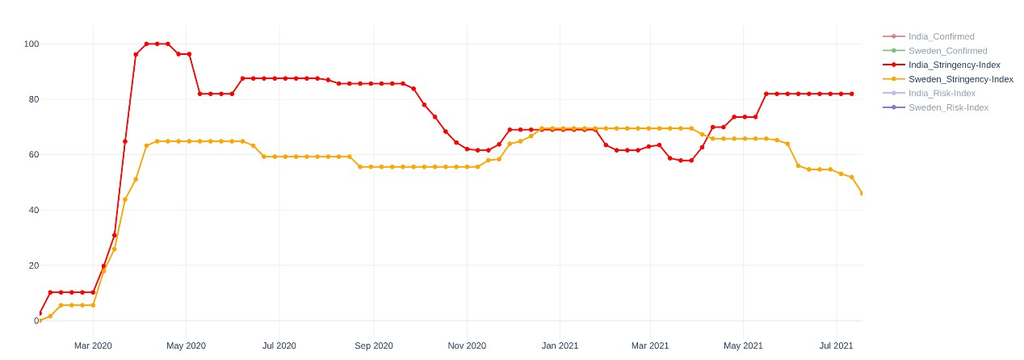

#### II.2.2 Confirmed Cases

We plot the number of confirmed cases of COVID-19 over time for Sweden and India respectively.

[figure not shown]

[figure not shown]

#### II.2.3 Mobility

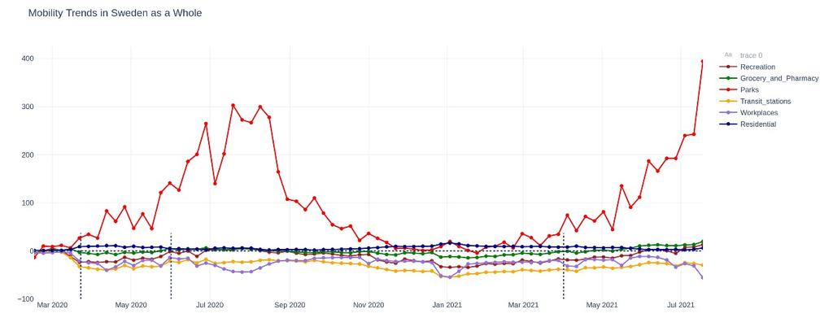

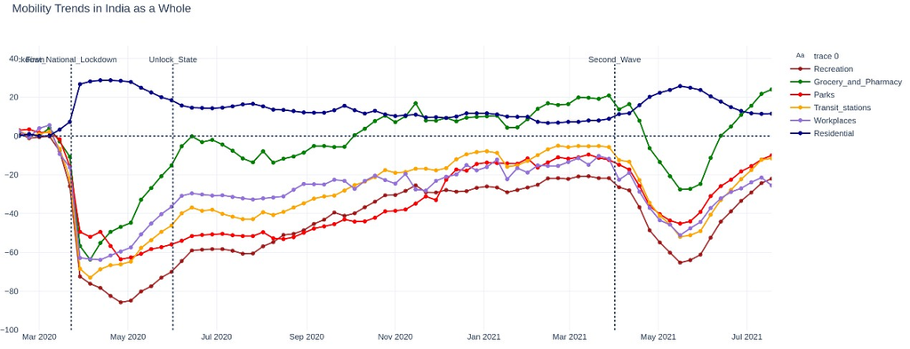

## III. Methods

### III.2 Bootstrap

#### III.2.1 Stratified Bootstrap estimation of the difference of means

Since we have to make use of the data of two countries, we assume that these two samples are independent.
$$X_{1},...,X_{n}\overset{\text{i.i.d}}{\sim} F$$
$$Y_{1},...Y_{m}\overset{\text{i.i.d}}{\sim} G$$
To get a rough idea of the data, we would like to compare the mean by calculating *the difference of means* (Fredrickson, 2021):
$$\bigtriangleup=E(X)-E(Y)$$
We’ll use the bootstrap method in the two sets of data separately to get estimates of means and then combine them. The `statistic` argument in `boot` function is the difference of mean of the two groups.
To deal with two groups of data, we have to combine them into a single dataset to do the bootstrap. One way to sort out one group from another is by using a flag indicator, with data from one set marked as “True” and the other marked as “False”.

#### III.2.2 Parametric Bootstrap (The residual is estimated using CLT method)

When we want to investigate on some important values of $x$, we treat these values as fixed, and sampled a varying number of $Y_i$ for each $x$ value. We want to model this conditional distribution of $Y \, | \, x$ as:
$$Y \, | \, x = \beta_0 + \beta_1 x + \epsilon$$
where $\beta_1 = \frac{\text{Cov}(X,Y)}{\text{Var}(X)}$, $\beta_0 = E(Y) - \beta_1 E(X)$, $E(\epsilon) = 0$ and $Var(\epsilon)$ is independent with $x$.

Since the normal distribution has “light tails” and assumptions based on normality can be sensitive to outliers, we decide to model $\epsilon$ with a scaled $t$-distribution with 4 degrees of freedom:
$$\epsilon \sim \frac{\sigma}{\sqrt{2}} t(4) \Rightarrow \text{Var}(\epsilon) = \sigma^2$$
(The $\sqrt{2}$ scale the $t$-distribution to have a variance of 1.)

To get an estimate of the distribution of $\hat \beta_1$, we first Estimate $\beta_0$, $\beta_1$, and $\sigma$ using linear regression. For all the $x_i$ in the sample, generate $\hat y_i = \hat \beta_0 + \hat \beta_1 x_i$. For $B$ replications, generate $Y_i^* = \hat y_i + \epsilon_i*$, where $\epsilon^* \sim \frac{\hat \sigma}{\sqrt{2}} t(4)$. For each replication, use linear regression to estimate $\hat \beta_1^*$. Finally, use the $\alpha/2$ and $1 - \alpha/2$ quantiles of the bootstrap distribution to get the confidence intervals: $[2 \hat \beta_1 - \hat \beta_1^*(1 - \alpha/2), 2 \hat \beta_1 - \hat \beta_1^*(\alpha/2)]$

#### III.2.3 Parametric Bootstrap (The residual is estimated using non-parametric method)

Instead of applying the CLT theorem and sampling from an assumed distribution for $\epsilon$, we can draw a sample with replacement from $\hat \epsilon_i$ and make $Y_i^* = \hat y_i + \epsilon_i^*$

### III.3 Permutation Test of Independence

To understand the relation of government policy on mobility and condition of the pandemic, we have to first test whether the three sets of data we found in the data section are inner related. Therefore, we need to do some independence tests.
Suppose we have a single sample of pairs
$$(W_{i},Z_{i}),i=1,...,n,IID.$$
Under the hypothesis that $F_{WZ}=F_{W}F_{Z}$ holds when they are independent, we could arbitrarily permute all the Z values and any statistic $T(W,Z)$ would have the same distribution. We could test this hypothesis with a test statistic for pairs(Fredrickson, 2021). In this case,we sample the correlation of the pair elements. If the p-value we get for this test is very small, we then could reject the hypothesis that the pair of variables are independent at some confidence level.
(Reference: STAT4060J Homework 5)

### II.4 Stochastic processes based on SIR model

An important thing we notice which is inspired by Hsiang et al.(2020) is that there exists some stochastic processes that we can further explore. And instead of focusing on the mechanism of disease transmission and make assumptions on uncertain epepidemiological parameters, we can do something directly relating interventions to the change of confirmed cases. In this paper, we will explore *“how the Stringency Index affects growth rate of confirmed cases.”*

According to SIR model:
$$I(t) = I(0)e^{gt}$$
where $I(0)$ is the number of infections at the start of the process, $e$ is the Naperian base and $g$ is the growth rate of infections at each unit of time.

Then if we choose two time points $t_1$ and $t_2$ and calculate the natural logarithm difference which represents the relative growth rate, we can show that the growth rate of infections is equal to the difference of two principal parameters defined in SIR model: transmission rate $\phi$ and recovery rate $\gamma$:
$$log(I(t_1))-log(I(t_2)) = g = \phi - \gamma.$$
It is reasonable to assume that $\phi$ is time-invariant except that some policies like the lockdown or other restrictions and suggestions on people’s behavior are put forward. And the recovery rate also does not change much because of very short-run investments on the health system. Thus, the growth rate of the infection cases can be described as a function to policies affecting people’s behavior:
$$\Delta log(I(t)) = \beta_0 + \beta_1 P(t) + u(t)$$
where $\beta_0$ is the growth rate of confirmed cases in the absence of those policies, $\beta_1$ is the expected impact of the Stringency Index ($P(t)$) and $u(t)$ is an error term.

To estimate $\beta_1$, we will use four methods based on the checking of assumptions: Linear Regression, Non-Parametric Bootstrap and 2 Parametric Bootstraps. Details will be illustrated in the process of Simulation and Analysis Part.

## IV. Simulation & Analysis

### IV.1 Smoothed comparisons of Strigency Index between countries

Based on about 190 countries’ pair of Stringency Index and Covid-19 Confirmed Case Data, we want to first generate a broader view as to *“How does the stringency index change as the pandemic gets fiercer?”*

We set the date that the confirmed cases in a country first exceeded *5, 500, 5000* as the threshold time points and compare the corresponding distribution of the stringency index. We use the smooth method with ash library.

```r
dim(confirmed)
```

```
## [1] 192 543
```

Based on about 190 countries’ pair of Stringency Index and Covid-19 Confirmed Case Data, we first generate a broader view as to *“How does the stringency index change as the pandemic gets fiercer?”*

we set the date that the confirmed cases in a country first exceeded *5, 500, 5000* as the threshold time points and compare the corresponding distribution of the index. We use the smooth method with ash library.

(As there are some countries missing one of the two data, the number of total pairs we consider are a little less than the total number of countries the original data-sets provide.)

The smoothing process of generating the distribution when confirmed cases exceed *5* is in the appendix file.

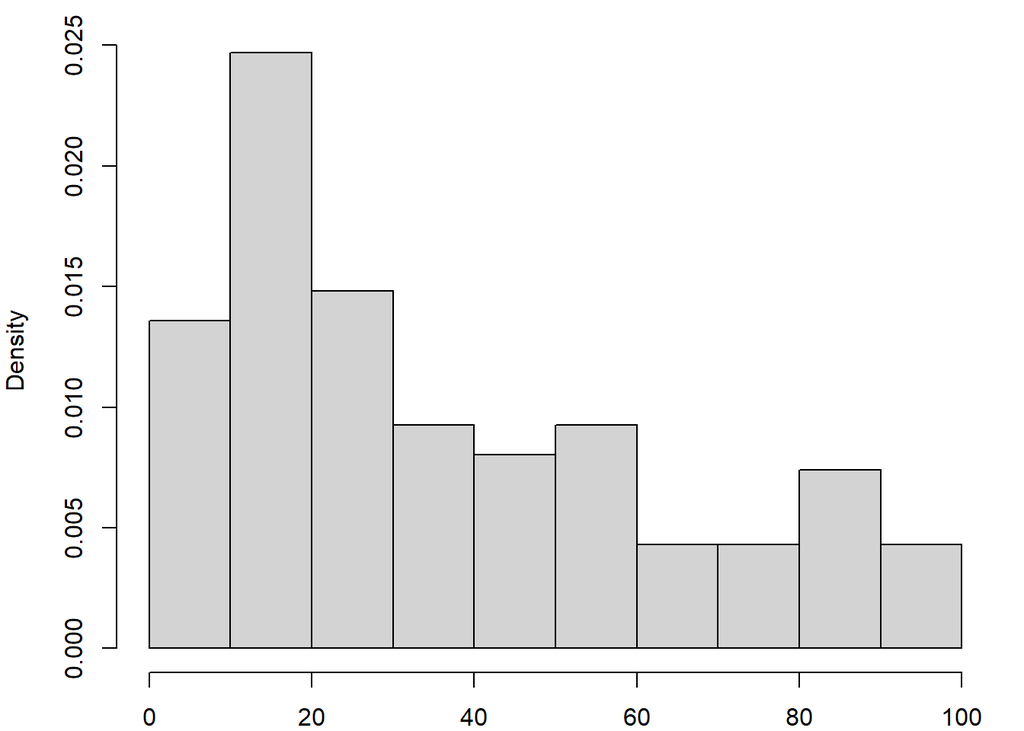

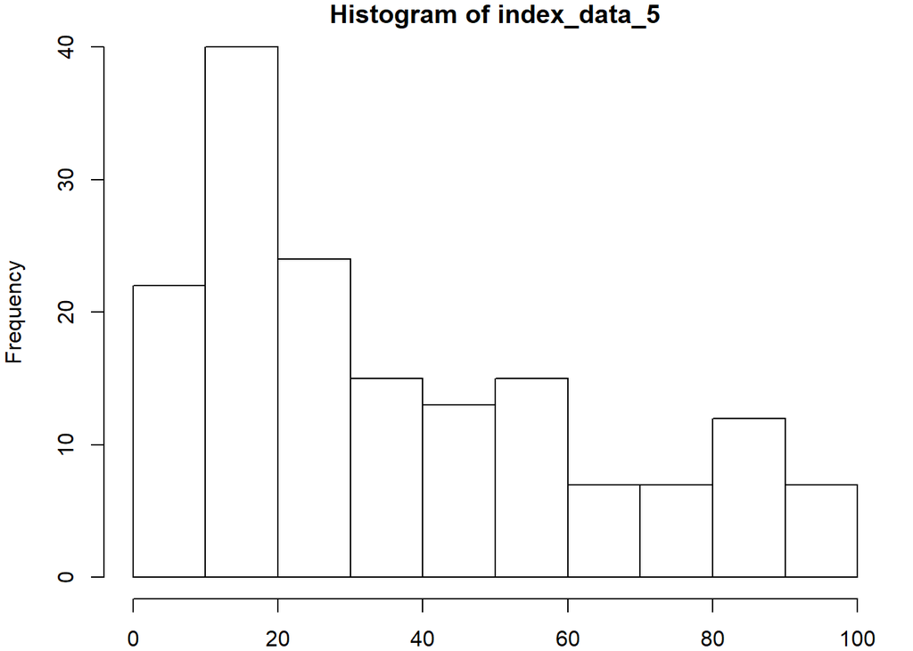

```
## [1] "ash estimate nonzero outside interval ab"
```

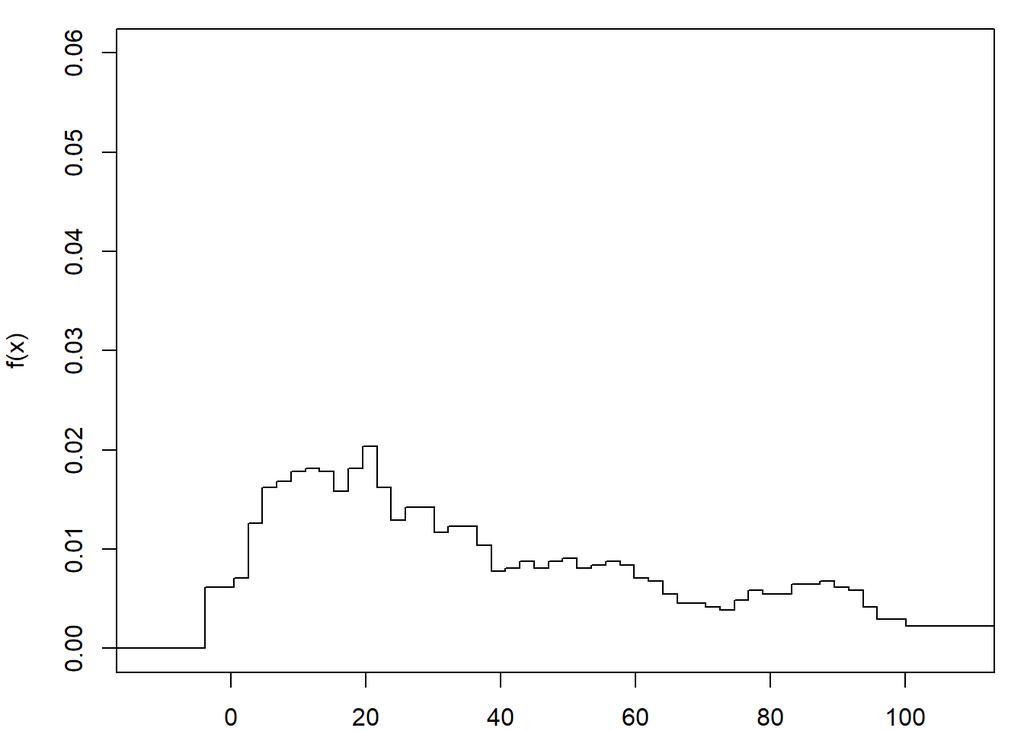

The same process are applied for exceeding *500* and *5000* cases.

Exceed 500 cases:

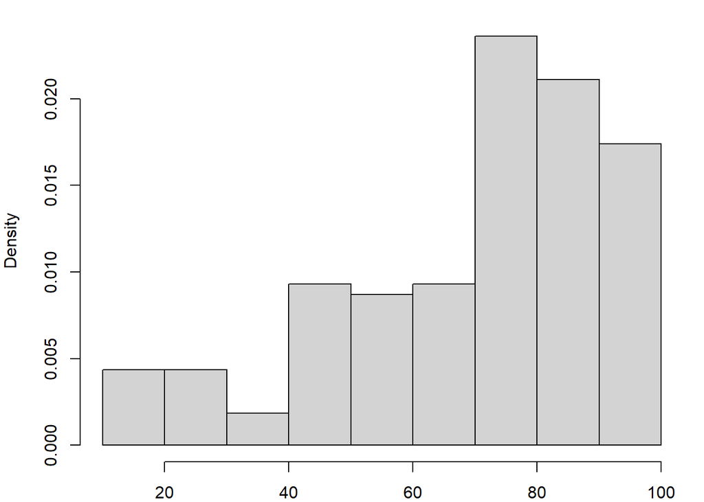

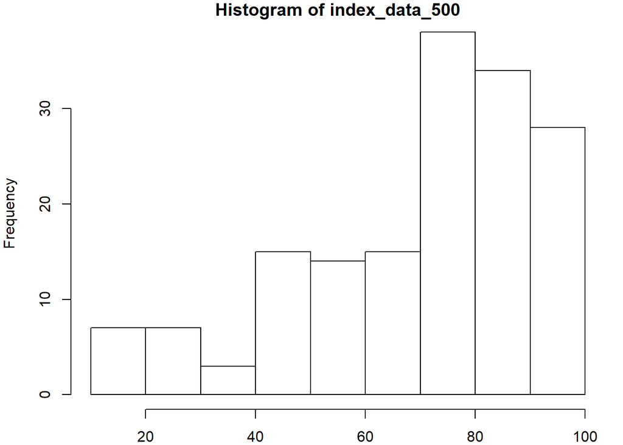

```
## [1] "ash estimate nonzero outside interval ab"
```

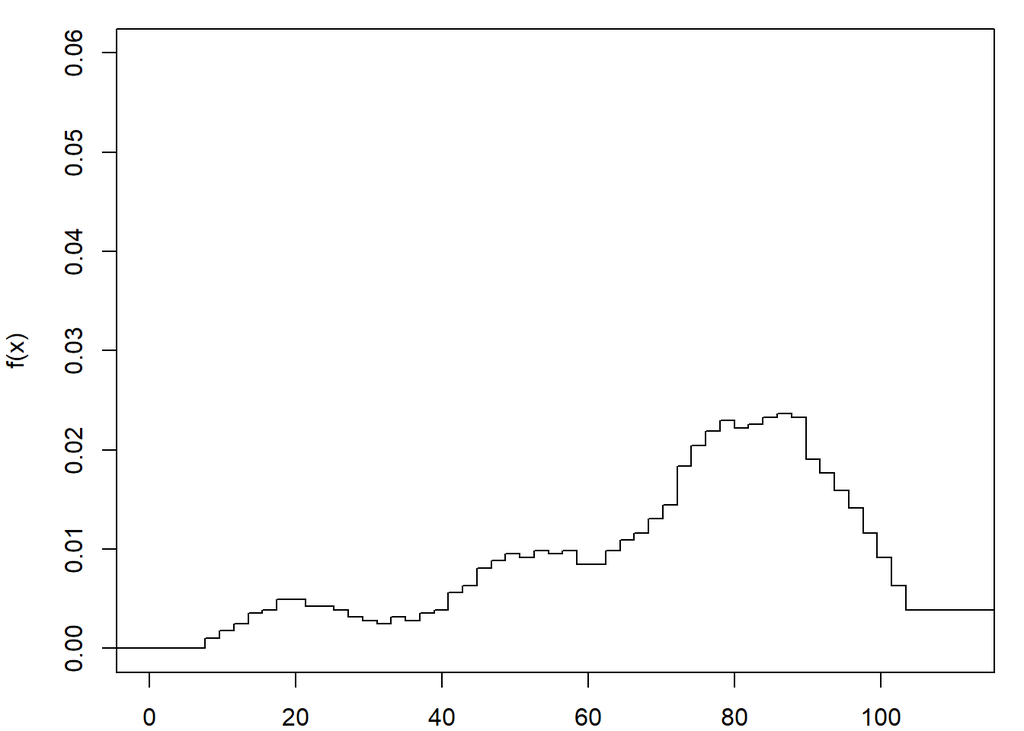

Exceed 5000 cases:

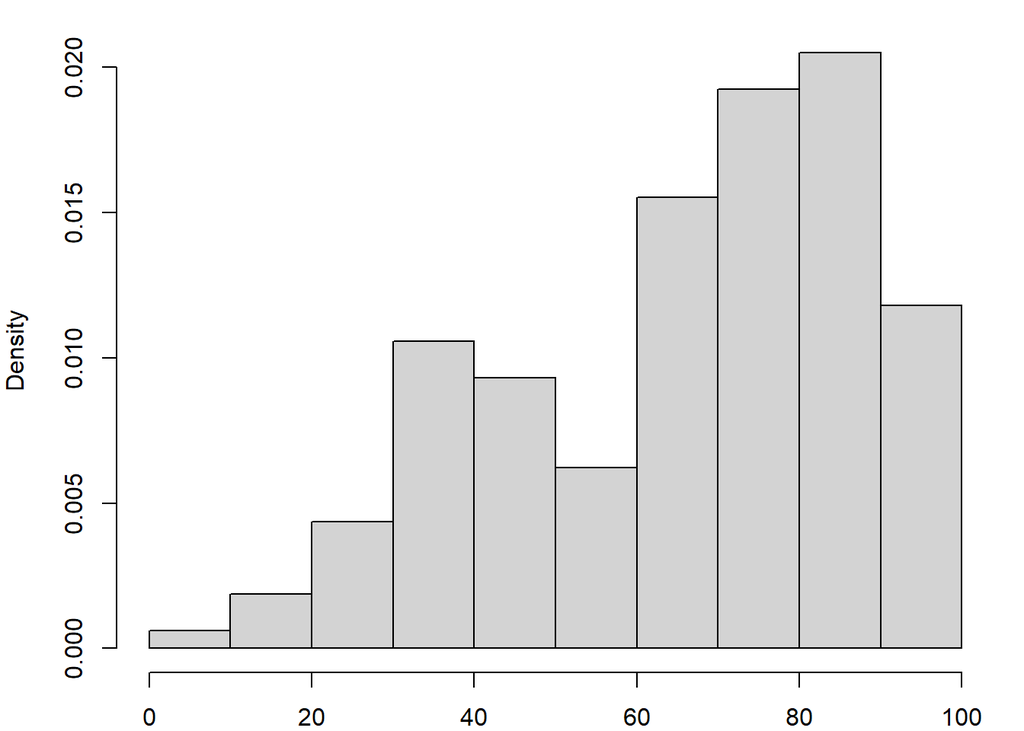

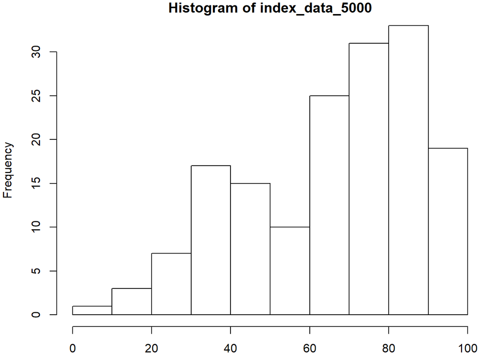

```
## [1] "ash estimate nonzero outside interval ab"
```

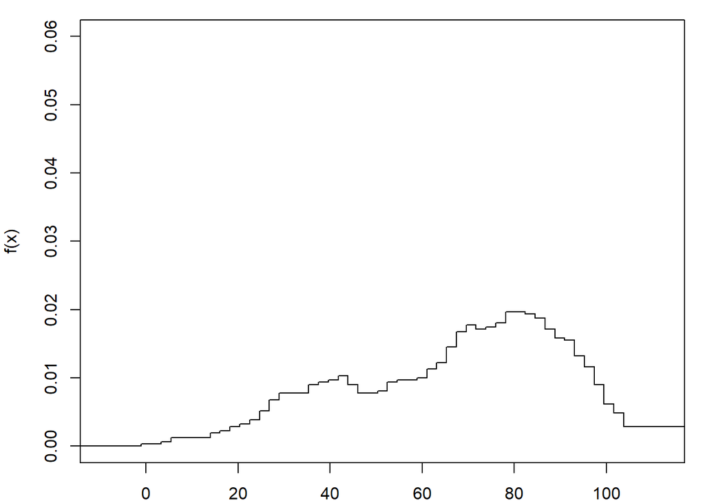

As is shown in the above plots, stringency index tends to be larger as the pandemic gets fiercer, which means more countries tend to use stricter policy as the pandemic gets fiercer. Then it is reasonable to say that more countries believe stricter policies on mobility will help overcome the pandemic. So *how does the stringency index actually impact confirmed cases and mobility?*

### IV.2 Bootstrap Test of mean on two samples on Stringency and Mobility Index of Sweden and India

We extract the recreation and residential index of Sweden and India, and combined them with the confirmed number of cases and stringency index from 2020.2.20 to 2021.2.20 respectively.We would like to compare the distribution of stringency index, recreation index and residential index of these two countries. Our hypothesis is: Sweden and India have different means of stringency index, movability index including recreation and residential index. To be specific, the null hypothesis are:India has a higher mean stingency index than Sweden, a larger mean recreation index than Sweden, and a larger mean residential index than Sweden.  
To do this, we add a label of `country_TF`. Swedish data will have a `country_TF=FALSE`, while Indian data will have `country_TF=TRUE`.

First, we test the mean of stringency index for Sweden and India.

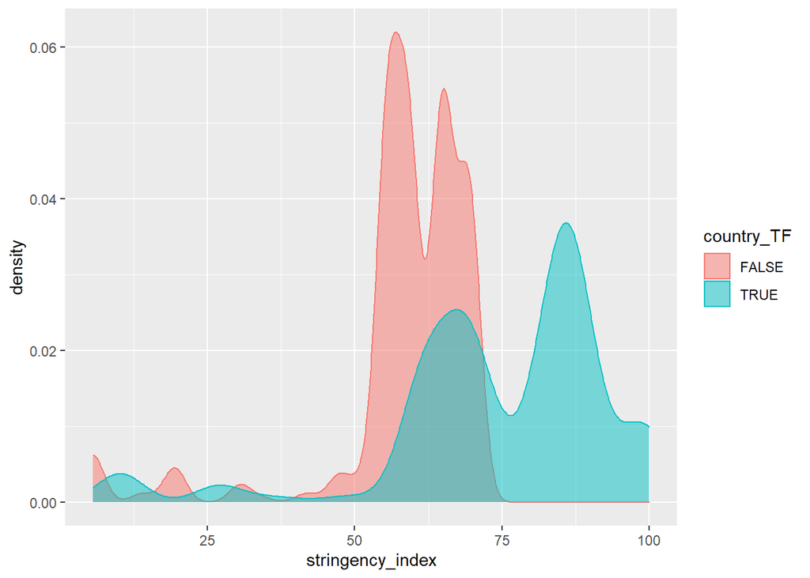

```
## BOOTSTRAP CONFIDENCE INTERVAL CALCULATIONS
## Based on 1000 bootstrap replicates
##
## CALL :
## boot.ci(boot.out = country_stringency.boot, type = c("basic",
##     "norm", "perc"))
##
## Intervals :
## Level      Normal              Basic              Percentile
## 95%   (13.94, 18.73 )   (14.07, 18.70 )   (14.04, 18.67 )
## Calculations and Intervals on Original Scale
```

We could see from the plot that India have higher stringency index than Sweden most of the times.And the confidence interval of the difference of their mean is (13.94, 18.73) using “normal” mode, and the other 2 modes are approximately the same, which does not include zero on 95% confidence level. Therefore, it agrees with our hypothesis than India have higher mean stringency index.

Then, we test the mean of recreation index for Sweden and India.

[figure not shown]

```
## BOOTSTRAP CONFIDENCE INTERVAL CALCULATIONS
## Based on 1000 bootstrap replicates
##
## CALL :
## boot.ci(boot.out = country_recreation.boot, type = c("basic",
##     "norm", "perc"))
##
## Intervals :
## Level      Normal              Basic              Percentile
## 95%   (11.54, 14.45 )   (11.48, 14.41 )   (11.53, 14.47 )
## Calculations and Intervals on Original Scale
```

Finally, we test the mean of residential index for Sweden and India.

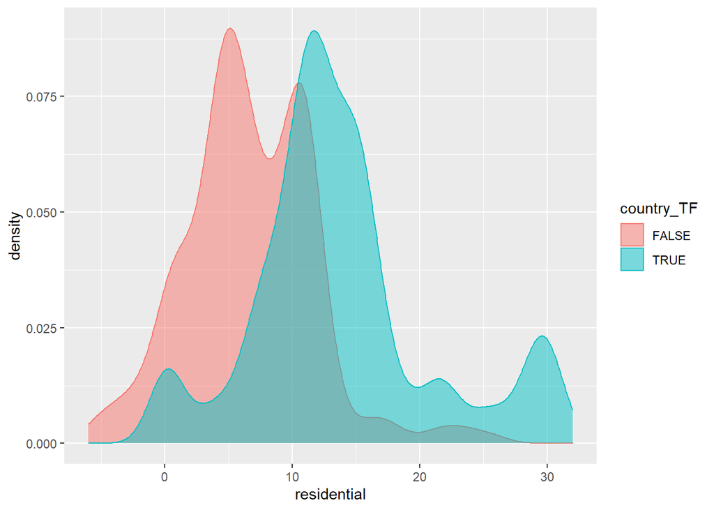

```
## BOOTSTRAP CONFIDENCE INTERVAL CALCULATIONS
## Based on 1000 bootstrap replicates
##
## CALL :
## boot.ci(boot.out = country_residential.boot, type = c("basic",
##     "norm", "perc"))
##
## Intervals :
## Level      Normal              Basic              Percentile
## 95%   ( 6.219,  8.004 )   ( 6.199,  8.038 )   ( 6.158,  7.997 )
## Calculations and Intervals on Original Scale
```

### IV.3 Permutation Test of Independence

As we have observed in the visualization part, recreational index and residential factor may be influenced by the government policy, and the policy could further influence the condition of the pandemic. Then we would like to explore the possible relationship between government policy, population mobility and confirmed number of people. If there exist correlation between each pair of factors, we could conclude that government policy on mobility could influence the number of confirmed cases. To achieve this goal, we first perform a permutation test for independence.Sample correlation is used to summarize the linear relationship between two variables

For Swedish and India, we test the correlation between *stringency index* and *confirmed cases* as well as *stringency index* and *mobility*.  
The null hypothesis is: (1) Stringency index and number of confirmed cases are independent.(2)Stringency index and mobility(recreation/residual) are independent.

We first perform test for independence on Sweden.

Stringency index v.s. confirmed cases

```
## [1] 0
```

Stringency index v.s. residual index

```
## [1] 0
```

Stringency index v.s. recreation index

```
## [1] 0
```

All three tests shows the p-value to be 0, we could reject the hypothesis(1)(2) that *stringency index* and *confirmed cases* as well as *stringency index* and *mobility* are independent at 5% significance level.  
The same tests are performed on India, which also results in p-values of 0. The detailed code is in the appendix files.

Therefore,we reach the conclusion that for both countries, stringency index is correlated to confirmed number of people and mobility in some ways. We will explore the relationship in the next section.

#### How Strigency Index Affects Confirmed Cases Growth Rate?

Process the data on *Confirmed Cases* and *Stringency Index* of the two countries and get the growth rate of the confirmed cases as illustrated in the method. Considering the complicity and validity of the data, we choose the period from *2020-2-20 to 2021-2-20*, which contains *367* days. Part of the processed data are listed below:

```
##           Date Sweden   India  growth_swe growth_ind stri_swe stri_ind
## 229 2020-09-06  84985 4204613 0.000000000 0.02183241    55.56    85.65
## 230 2020-09-07  85558 4280422 0.006719738 0.01786935    55.56    85.65
## 231 2020-09-08  85707 4370128 0.001739994 0.02074070    55.56    85.65
## 232 2020-09-09  85880 4465863 0.002016470 0.02167018    55.56    85.65
## 233 2020-09-10  86194 4562414 0.003649597 0.02138939    55.56    85.65
## 234 2020-09-11  86505 4659984 0.003601646 0.02116015    55.56    85.65
```

#### Linear Regresstion

As is illustrated in the method, we assumes a linear relationship between the case growth rate and the index. We first use the lm function in R to estimate $\beta_0$ and $\beta_1$ using sample means and variances.

```
##  (Intercept)     stri_swe
##  0.297009832 -0.004488095
```

```
##                    2.5 %       97.5 %
## (Intercept)  0.259044690  0.334974974
## stri_swe    -0.005124462 -0.003851728
```

```
##   (Intercept)      stri_ind
##  0.0737993886 -0.0004396873
```

```
##                     2.5 %       97.5 %
## (Intercept)  0.0318387966 0.1157599807
## stri_ind    -0.0009847821 0.0001054075
```

As this estimation quality is closely related to the validity of the Central Limit Theorem Approximation, here we check the quality of the CLT approximation for the confidence interval produced above by the shape of the distribution of the residuals R.

(Check Validity of the Central Limit Theorem Approximation)

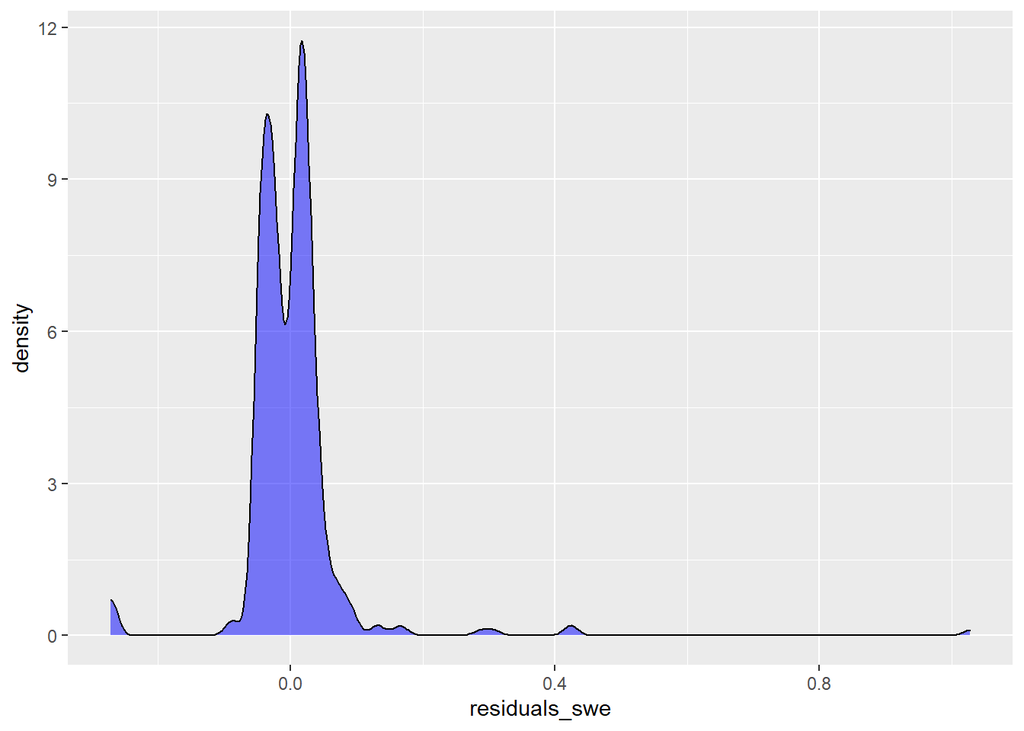

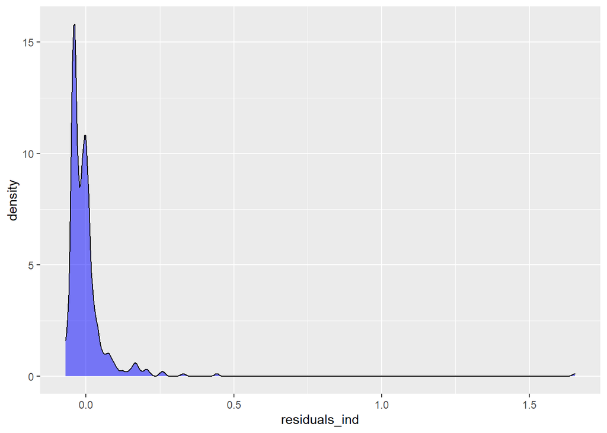

#### Bootstrap

The assumptions of bootstrap includes:

1. $T \approx θ$: n is large enough so that the estimator can be assumed to be close to the true value.
2. $\hat F \approx F$: n is large enough so that the empirical CDF can be assumed to be close to the true CDF.
3. $F^* \approx F$: B is large enough so that the CDF of the bootstrap samples can be assumed to be close to the true CDF.

In this case, n=367 and B is set to be 1000. Thus, the assumptions are met and bootstrap can be used.

Here we use 3 bootstrap methods: 1 Non-Parametric and 2 Parametric.

Non-Parametric Bootstrap for Sweden

```
## BOOTSTRAP CONFIDENCE INTERVAL CALCULATIONS
## Based on 1000 bootstrap replicates
##
## CALL :
## boot.ci(boot.out = boot_b, type = c("basic", "perc"), index = 2)
##
## Intervals :
## Level      Basic              Percentile
## 95%   (-0.0065, -0.0020 )   (-0.0070, -0.0024 )
## Calculations and Intervals on Original Scale
```

Non-Parametric Bootstrap for India

```
## BOOTSTRAP CONFIDENCE INTERVAL CALCULATIONS
## Based on 1000 bootstrap replicates
##
## CALL :
## boot.ci(boot.out = boot_b, type = c("basic", "perc"), index = 2)
##
## Intervals :
## Level      Basic              Percentile
## 95%   (-0.0017,  0.0013 )   (-0.0022,  0.0008 )
## Calculations and Intervals on Original Scale
```

Parametric Bootstrap for Sweden

```
## [1] -0.005139489 -0.003863477
```

Parametric Bootstraps Residuals for Sweden

```
## [1] -0.005081983 -0.003761433
```

```
## [1] -9.613670e-04  9.231163e-05
```

Parametric Bootstraps Residuals for India

```
## [1] -0.0009586348  0.0002325203
```

The summary of the four generated confidence intervals of $\beta_1$:

[output not shown]

As is shown in the table, no matter which method is used and regardless the difference in power (parametric ones have more power), the confidence intervals of $\beta_1$ for Sweden is always negative, meaning *“Larger Stringency Index can effectively decrease the growth rate of confirmed cases.”* and this corresponds to our original thought. However, the confidence intervals of $\beta_1$ for India contains positive numbers, meaning *“Sometimes larger Stringency Index may even increase the growth rate of confirmed cases.”* Is this because stricter policies do not effectively lead to a decrease in mobility in recreation(for example), that can help reduce contact between people in India?

### IV.5 The relationship between mobility and stringency index

To know whether government stringency does have impact on the mobility of people, we would like to do a hypothesis test by letting the null hypothesis to be

Particularly, we would like to explore: (1)
$$H_0: \text{the recreation index is positive correlated to stringency index}$$
(2)
$$H_0: \text{the residential index is positive correlated to stringency index}$$

```
##                                   2.5 %     97.5 %
## (Intercept)                   5.4612741 17.5541337
## sweden_full$stringency_index -0.5215924 -0.3191664
```

```
##                                 2.5 %     97.5 %
## (Intercept)                 25.666387 35.3295323
## india_full$stringency_index -1.065105 -0.9397424
```

We apply linear regression method in R to find out the confidence interval of the relationship coeficient $\beta_1$.

For recreation index and stringency, the 95% confidence interval of the relationship coeficient $\beta_1$ for Sweden is [-0.5216, -0.3192]. We reject the null hypothesis1 at significance level $\alpha = 0.025$.

The 95% confidence interval of the relationship coeficient $\beta_1$ for India is [-1.065, -0.9397]. We reject the null hypothesis1 at significance level $\alpha = 0.025$.

```r
lmsw = lm(sweden_full$residential ~ sweden_full$stringency_index)
confint(lmsw, level = 0.95)
```

```
##                                   2.5 %     97.5 %
## (Intercept)                  -4.9412786 -0.7470688
## sweden_full$stringency_index  0.1287468  0.1989549
```

```r
lmin = lm(india_full$residential ~ india_full$stringency_index)
confint(lmin, level = 0.95)
```

```
##                                  2.5 %     97.5 %
## (Intercept)                 -9.7512151 -6.2015280
## india_full$stringency_index  0.2688118  0.3148629
```

For residential index and stringency, the 95% confidence interval of the relationship coeficient $\beta_1$ for Sweden is [0.1288,0.1990] We accept the null hypothesis2 at significance level $\alpha = 0.025$.

The 95% confidence interval of the relationship coeficient $\beta_1$ for India is [0.2688118,0.3148629]. We accept the null hypothesis2 at significance level $\alpha = 0.025$.

Thus, we may conclude that, the mobility is correlated to the stringency index, and whether it is positively or negatively related depend on which kind of index. The raise up of government stringency do help to limit the mobility of people, therefore we could see a decline in recreation and an increase in residual index followed by the government policy of keeping social distance, since more people prefer to stay indoors.

Moreover, for different countries, the levels of impact of government policy are different. Generally speaking, government stringency has more significant impact on the mobility of people in India than in Sweden.

### V. Discussion

In this project, we explored the impact of government policy on people’s mobility over the control of COVID-19 pandemic. By using the daily data including stringency index, confirmed cases population mobility, we researched over these three sets of data. We completed the following tasks:

[output not shown]

*Now here comes the questions:*

India put forward very strict policies on people’s mobility. (After its confirmed cases exceeds 5 (2020-03-02), its stringency index increases rapidly and within 20 days, the index increases from 10.19 to near 100.) On the contrary, Sweden has much less strict policies than India.

As controlled mobility will decrease contact and thus impose a positive affect on reducing confirmed case growth rate, then why high stringency index in India actually may sometimes increase the growth rate under the circumstances where the mobility has been successfully controlled?

After searching more information, this might because:

The strict lockdown policy adopted by India has the following problems: 1. Adopting a strict lockdown strategy not suited to the Indian context; 2. The focus is most on mobility control, while other issues are ignored; 3. Insufficient investment and preparations in the health system, and lack of relief measures.

Specifically, about 95% of workers in India are informal and have no legal protection and also little social protection. The strict and sudden lockdown brought severe economic distress to these workers. However, there are also very little relief from the government. The total amount of additional public spending announced at the end of May is only about 1% of GDP, and most of it has not reached people; after 1 month of the lockdown, the majority (96%) did not receive food rations or cash relief from the government. This economic distress made people more vulnerable to health problems. Further, about one third of the urban population and at least a quarter of the rural population live in very crowded conditions in India, and the “stay at home” policy in this condition are even counterproductive. Access to clean water and daily necessities is inherently limited, and the strict bans have made the situation worse. In the early stage of the epidemic, India directly applied the strict lockdown policy, regardless of its own national conditions. When the economy and livelihood made the lockdown strategy unsustainable, it was forced to unlock when the epidemic became much more dangerous. (Jayati, 2020)

In the future, we might want to explore the problem over how government policy influence a pandemic. As for methods, in our projects we only use linear regression to test the relation between mobility and stringency index. Actually, we could perform Monte Carlo hypothesis test and bootstrap method to do this as well. Furthermore, we could implement some predictions based on stochastic process for the disease. As for data, we may look at other countries, and may explore other conditions of India that affect how their government policy work.

#### Citation

```
[1] Yilmazkuday, H. (2020). Stay-at-Home Works to Fight Against COVID-19: Interna-
tional Evidence from Google Mobility Data (April 9, 2020). Available at SSRN : https :
==papers:ssrn:com=sol3=papers:cfm?abstractid = 3571708
[2] Hale, Thomas, Anna Petherick, Toby Phillips, Samuel Webster. “Variation in Govern-
ment Responses to COVID-19” Version 4.0. Blavatnik School of Government Working Paper.
April 7, 2020. Available: www.bsg.ox.ac.uk/covidtracker10
[3] Ghosh, J. A critique of the Indian government’s response to the COVID-19 pandemic. J. Ind. Bus. Econ. 47, 519–530 (2020). https://doi.org/10.1007/s40812-020-00170-x
[4] Dergiades, T., Milas, C., & Panagiotidis, T. (2020). Effectiveness of government policies in response to the COVID-19 outbreak. Available at SSRN, 3602004.
[5 ]Mark Fredrickson, STAT4060J class materials, 2021 Summer.
```